# Chapter 11 - Clustering Analysis (part 2)

In this part of the tutorial, we will see an application of mixture models. These models can be fitted using the `Mclust` function, available in the `mclust` library. We will see two different examples: on simulated data and on real data.

## Mixture models on simulated data.

In order to understand how mixture models work, we will start by analyzing data simulated according to a mixture of Gaussian distributions - which corresponds exactly to the assumptions of the mixture model. These data represent an ideal scenario for using these models.

In the considered scenario, we consider a mixture of $K=3$ Gaussian populations. Two variables $X_1$ and $X_2$ are considered such that for each observation $i$ of population $k$:
$$(X_{1i},X_{2i})\sim \mathcal{MN}(\mu_k,\Sigma_k),$$

where $\mu_k=(\mu_{1k},\mu_{2k})$ and $\Sigma_k$ is an identical diagonal matrix for each population such that $diag(\Sigma_k)=(\sigma^2,\sigma^2)$. Here is the code to simulate these data:

```r
set.seed(12355)
mu1=matrix(runif(6),ncol=3)
mu1
```

```
##           [,1]      [,2]      [,3]
## [1,] 0.4267946 0.9900822 0.6471511
## [2,] 0.9210779 0.5738888 0.7516277
```

```r
mydata1=matrix(c(rnorm(200,mean=mu1[,1],sd=.01),
              rnorm(200,mean=mu1[,2],sd=.01),
              rnorm(200,mean=mu1[,3],sd=.01)), ncol=2,byrow=T)
colnames(mydata1) <- c("X1","X2")
head(mydata1)
```

```
##             X1        X2
## [1,] 0.4347266 0.9303407
## [2,] 0.4199264 0.9295048
## [3,] 0.4231781 0.9396562
## [4,] 0.4282378 0.9201448
## [5,] 0.4428544 0.9225690
## [6,] 0.4162656 0.9178361
```

```r
dim(mydata1)
```

```
## [1] 300   2
```

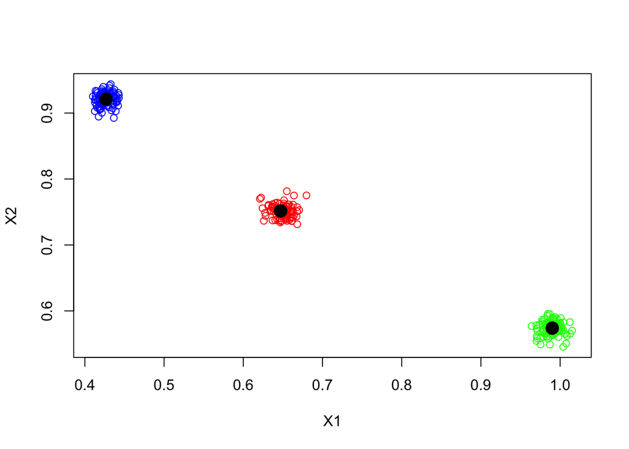

```r
plot(mydata1,col=rep(c("blue","green","red"),each=100))
points(t(mu1),pch=16,cex=2,col="black")
```

As we can see, the groups are extremely well separated and it will probably be very easy to find them using a mixture model. By increasing the variance of the Gaussian distributions, it is possible to simulate a little more “mixed” data, as below:

```r
set.seed(125)
mu2=matrix(runif(6),ncol=3)
mu2
```

```
##           [,1]      [,2]      [,3]
## [1,] 0.8246744 0.2997806 0.9651950
## [2,] 0.1168510 0.3565607 0.9675605
```

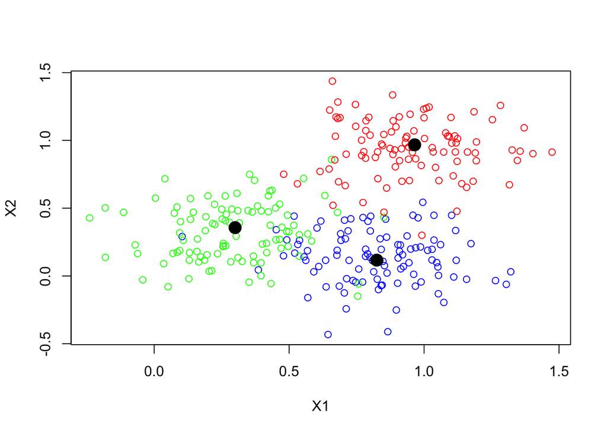

```r
mydata2=matrix(c(rnorm(200,mean=mu2[,1],sd=.2),
              rnorm(200,mean=mu2[,2],sd=.2),
              rnorm(200,mean=mu2[,3],sd=.2)), ncol=2,byrow=T)
colnames(mydata2) <- c("X1","X2")

plot(mydata2,col=rep(c("blue","green","red"),each=100))
points(t(mu2),pch=16,cex=2,col="black")
```

We will now fit a mixture model on these 2 data sets. For the first data set, the code is below:

```r
library(mclust)
model1=Mclust(mydata1)
summary(model1)
```

```
## ----------------------------------------------------
## Gaussian finite mixture model fitted by EM algorithm
## ----------------------------------------------------
##
## Mclust EII (spherical, equal volume) model with 3 components:
##
##  log-likelihood   n df      BIC      ICL
##        1585.662 300  9 3119.989 3119.989
##
## Clustering table:
##   1   2   3
## 100 100 100
```

The BIC graph for all models and all numbers of groups can be obtained with the following command:

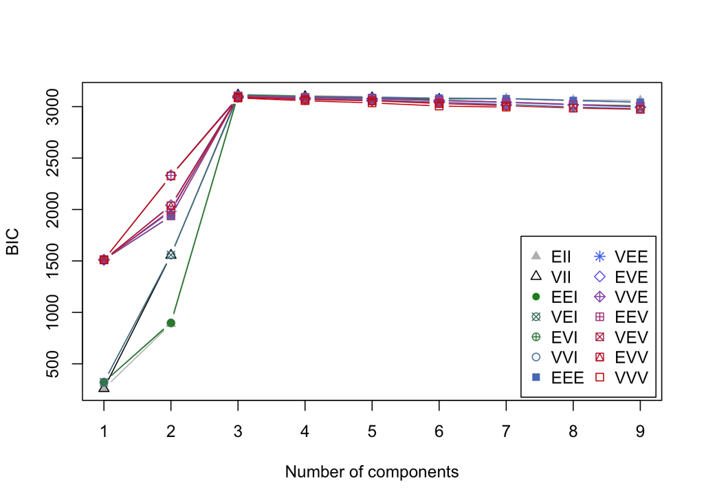

```r
plot(model1, what = "BIC")
```

Be careful, the function `Mclust` uses the negative version of the BIC that we defined in class. Except for one sign, the definition is the same, but here we try to maximize the BIC and not to minimize it. It is not clear from the graph whether the best model selected is indeed the EII model, but we can see the BIC values with the following function:

```r
model1$BIC
```

```
## Bayesian Information Criterion (BIC):
##         EII       VII       EEI       VEI       EVI       VVI      EEE      VEE
## 1  259.1006  259.1006  321.8016  321.8016  321.8016  321.8016 1510.959 1510.959
## 2  888.0911 1554.8663  902.5646 1558.6262  896.9436 1557.0544 1933.408 1981.776
## 3 3119.9893 3111.7756 3114.2875 3106.1346 3106.9503 3099.0429 3108.586 3100.454
## 4 3105.8595 3096.2230 3100.1349 3090.6230 3088.9239 3076.0077 3095.080 3085.345
## 5 3096.5772 3083.9430 3090.9232 3078.6190 3084.3688 3062.2713 3088.901 3072.579
## 6 3082.7966 3068.9078 3075.1294 3063.8111 3063.9195 3042.1825 3082.340 3058.634
## 7 3081.8306        NA 3076.3274        NA 3042.3113 3021.3693 3076.423       NA
## 8 3064.7137        NA 3059.2208        NA 3019.4922 2997.0122 3059.303       NA
## 9 3060.4312        NA 3042.4760        NA 3008.3360 2977.8839 3042.318       NA
##        EVE      VVE      EEV      VEV      EVV      VVV
## 1 1510.959 1510.959 1510.959 1510.959 1510.959 1510.959
## 2 2041.942 2331.405 1937.968 1995.595 2036.246 2325.767
## 3 3102.825 3094.902 3102.214 3094.275 3091.819 3083.889
## 4 3085.803 3073.748 3085.463 3073.427 3069.451 3057.127
## 5 3077.182 3056.645 3080.270 3059.008 3056.599 3036.088
## 6 3057.803 3042.940 3060.562 3036.730 3029.937 3005.836
## 7 3039.879 3014.664 3044.815       NA 3008.779 2995.074
## 8 3017.102       NA 3022.341       NA 2986.035       NA
## 9 2994.227       NA 2999.973       NA 2973.604       NA
##
## Top 3 models based on the BIC criterion:
##    EII,3    EEI,3    VII,3
## 3119.989 3114.288 3111.776
```

The model parameters can be obtained with the following command:

```r
model1$parameters
```

```
## $pro
## [1] 0.3333333 0.3333333 0.3333333
##
## $mean
##         [,1]      [,2]      [,3]
## X1 0.4267866 0.9894631 0.6494069
## X2 0.9214981 0.5736744 0.7506770
##
## $variance
## $variance$modelName
## [1] "EII"
##
## $variance$d
## [1] 2
##
## $variance$G
## [1] 3
##
## $variance$sigma
## , , 1
##
##              X1           X2
## X1 9.883801e-05 0.000000e+00
## X2 0.000000e+00 9.883801e-05
##
## , , 2
##
##              X1           X2
## X1 9.883801e-05 0.000000e+00
## X2 0.000000e+00 9.883801e-05
##
## , , 3
##
##              X1           X2
## X1 9.883801e-05 0.000000e+00
## X2 0.000000e+00 9.883801e-05
##
##
## $variance$Sigma
##              X1           X2
## X1 9.883801e-05 0.000000e+00
## X2 0.000000e+00 9.883801e-05
##
## $variance$sigmasq
## [1] 9.883801e-05
##
## $variance$scale
## [1] 9.883801e-05
##
##
## $Vinv
## NULL
```

We can see that the mixing probabilities for the 3 populations are estimated at 1/3 each, which corresponds to the reality of the data. We can compare the estimated means for the 3 populations with the true means:

```r
model1$parameters$mean
```

```
##         [,1]      [,2]      [,3]
## X1 0.4267866 0.9894631 0.6494069
## X2 0.9214981 0.5736744 0.7506770
```

```r
mu1
```

```
##           [,1]      [,2]      [,3]
## [1,] 0.4267946 0.9900822 0.6471511
## [2,] 0.9210779 0.5738888 0.7516277
```

We can see that the means are very well estimated. We can also compare the values of the estimated variances with the real variances:

```r
model1$parameters$variance$Sigma
```

```
##              X1           X2
## X1 9.883801e-05 0.000000e+00
## X2 0.000000e+00 9.883801e-05
```

```r
Vraie_variance=0.01^2
Vraie_variance
```

```
## [1] 1e-04
```

Again, we can see that the variance parameters are very well estimated by the model.

The values of the posterior probabilities for each group and each observation can be found in the `z` object:

```r
head(model1$z)
```

```
##      [,1] [,2]          [,3]
## [1,]    1    0 1.375785e-172
## [2,]    1    0 1.943067e-186
## [3,]    1    0 7.075799e-191
## [4,]    1    0 2.781015e-171
## [5,]    1    0 8.364757e-159
## [6,]    1    0 2.923669e-181
```

```r
dim(model1$z)
```

```
## [1] 300   3
```

```r
model1$z[100:110,]
```

```
##       [,1] [,2]          [,3]
##  [1,]    1    0 2.255070e-167
##  [2,]    0    1  0.000000e+00
##  [3,]    0    1  0.000000e+00
##  [4,]    0    1  0.000000e+00
##  [5,]    0    1  0.000000e+00
##  [6,]    0    1  0.000000e+00
##  [7,]    0    1 3.580964e-300
##  [8,]    0    1  0.000000e+00
##  [9,]    0    1  0.000000e+00
## [10,]    0    1 8.210618e-291
## [11,]    0    1  0.000000e+00
```

```r
model1$z[200:210,]
```

```
##                [,1]          [,2] [,3]
##  [1,]  0.000000e+00  1.000000e+00    0
##  [2,] 4.933067e-168  0.000000e+00    1
##  [3,] 1.196389e-178  0.000000e+00    1
##  [4,] 4.572879e-185 2.934329e-297    1
##  [5,] 4.480839e-168  0.000000e+00    1
##  [6,] 6.971914e-191 2.533891e-300    1
##  [7,] 3.705855e-196 1.022123e-294    1
##  [8,] 5.055682e-174  0.000000e+00    1
##  [9,] 7.539391e-185 1.077268e-306    1
## [10,] 1.951509e-162  0.000000e+00    1
## [11,] 4.412746e-179  0.000000e+00    1
```

Here again, we can see that the estimated probabilities are very high for the population to which the observation belongs, and almost null for the other populations. Based on a classification of the observations according to the highest posterior probability, the classification can be obtained as follows:

```r
model1$classification
```

```
##   [1] 1 1 1 1 1 1 1 1 1 1 1 1 1 1 1 1 1 1 1 1 1 1 1 1 1 1 1 1 1 1 1 1 1 1 1 1 1
##  [38] 1 1 1 1 1 1 1 1 1 1 1 1 1 1 1 1 1 1 1 1 1 1 1 1 1 1 1 1 1 1 1 1 1 1 1 1 1
##  [75] 1 1 1 1 1 1 1 1 1 1 1 1 1 1 1 1 1 1 1 1 1 1 1 1 1 1 2 2 2 2 2 2 2 2 2 2 2
## [112] 2 2 2 2 2 2 2 2 2 2 2 2 2 2 2 2 2 2 2 2 2 2 2 2 2 2 2 2 2 2 2 2 2 2 2 2 2
## [149] 2 2 2 2 2 2 2 2 2 2 2 2 2 2 2 2 2 2 2 2 2 2 2 2 2 2 2 2 2 2 2 2 2 2 2 2 2
## [186] 2 2 2 2 2 2 2 2 2 2 2 2 2 2 2 3 3 3 3 3 3 3 3 3 3 3 3 3 3 3 3 3 3 3 3 3 3
## [223] 3 3 3 3 3 3 3 3 3 3 3 3 3 3 3 3 3 3 3 3 3 3 3 3 3 3 3 3 3 3 3 3 3 3 3 3 3
## [260] 3 3 3 3 3 3 3 3 3 3 3 3 3 3 3 3 3 3 3 3 3 3 3 3 3 3 3 3 3 3 3 3 3 3 3 3 3
## [297] 3 3 3 3
```

Finally, we can visualize the grouping graphically with the following function:

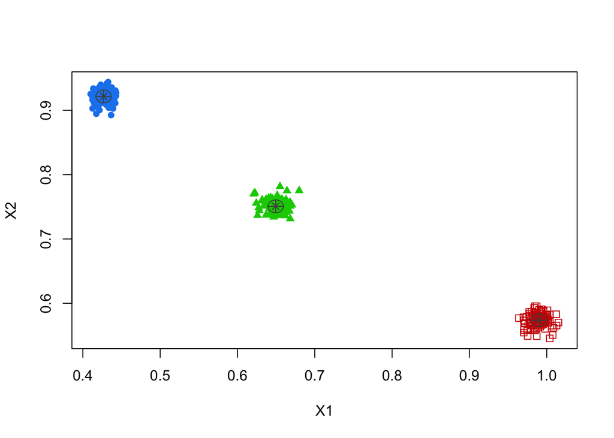

```r
plot(model1, what = c("classification"))
```

Of course, the example we have worked with so far is trivial. Let’s start the same analysis again with the less perfect data we have generated:

```r
model2=Mclust(mydata2)
summary(model2)
```

```
## ----------------------------------------------------
## Gaussian finite mixture model fitted by EM algorithm
## ----------------------------------------------------
##
## Mclust EII (spherical, equal volume) model with 3 components:
##
##  log-likelihood   n df       BIC       ICL
##       -162.2961 300  9 -375.9262 -422.2672
##
## Clustering table:
##   1   2   3
##  96 109  95
```

We can see that the best model selected is the good EII model. However, the classification is no longer perfect, as we can also see graphically:

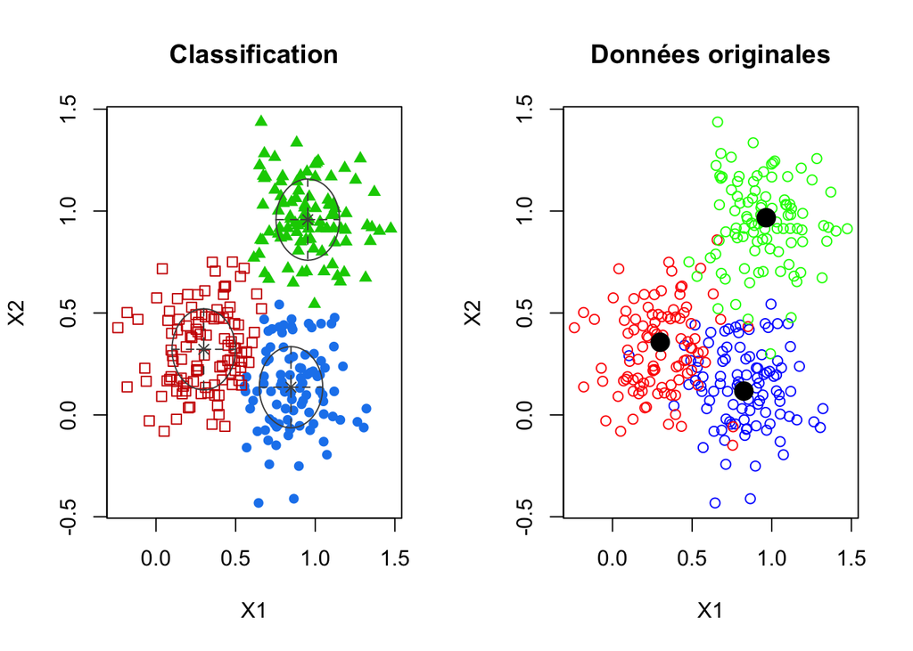

```r
par(mfrow=c(1,2))
plot(model2, what = c("classification"))
title("Classification")
plot(mydata2,col=rep(c("blue","red","green"),each=100))
points(t(mu2),pch=16,cex=2,col="black")
title("Données originales")
```

## Analysis of US arrest data

We will analyze here a data set available in R `USArrest` which contains the arrest statistics per 100,000 inhabitants for murder (variable `Murder`), assault (variable `Assault`) or rape (variable `Rape`) for 50 states of the United States in 1973. The proportion of people living in urban areas is also given in the variable `UrbanPop`. We will perform a clustering analysis using a mixture model on these 4 variables.

```r
head(USArrests)
```

```
##            Murder Assault UrbanPop Rape
## Alabama      13.2     236       58 21.2
## Alaska       10.0     263       48 44.5
## Arizona       8.1     294       80 31.0
## Arkansas      8.8     190       50 19.5
## California    9.0     276       91 40.6
## Colorado      7.9     204       78 38.7
```

```r
model=Mclust(USArrests)
summary(model)
```

```
## ----------------------------------------------------
## Gaussian finite mixture model fitted by EM algorithm
## ----------------------------------------------------
##
## Mclust VEI (diagonal, equal shape) model with 3 components:
##
##  log-likelihood  n df       BIC      ICL
##       -757.5594 50 20 -1593.359 -1597.95
##
## Clustering table:
##  1  2  3
## 20 10 20
```

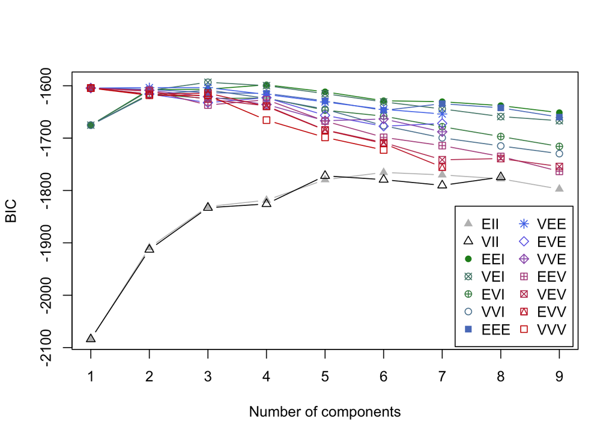

```r
plot(model, data=USArrests, what="BIC")
```

The best model is a VEI (diagonal, equal shape) model with 3 groups. We can see with the BIC graph that there is a large variation in the fit of these models.

The posterior probabilities of the groups are given below:

```r
round(model$z,2)
```

```
##                [,1] [,2] [,3]
## Alabama        1.00 0.00 0.00
## Alaska         1.00 0.00 0.00
## Arizona        1.00 0.00 0.00
## Arkansas       0.41 0.00 0.59
## California     1.00 0.00 0.00
## Colorado       1.00 0.00 0.00
## Connecticut    0.00 0.02 0.98
## Delaware       0.37 0.00 0.63
## Florida        1.00 0.00 0.00
## Georgia        1.00 0.00 0.00
## Hawaii         0.00 0.00 1.00
## Idaho          0.00 0.64 0.36
## Illinois       1.00 0.00 0.00
## Indiana        0.00 0.00 1.00
## Iowa           0.00 1.00 0.00
## Kansas         0.00 0.00 1.00
## Kentucky       0.01 0.00 0.99
## Louisiana      1.00 0.00 0.00
## Maine          0.00 1.00 0.00
## Maryland       1.00 0.00 0.00
## Massachusetts  0.00 0.00 1.00
## Michigan       1.00 0.00 0.00
## Minnesota      0.00 0.85 0.15
## Mississippi    1.00 0.00 0.00
## Missouri       0.66 0.00 0.34
## Montana        0.00 0.02 0.98
## Nebraska       0.00 0.10 0.90
## Nevada         1.00 0.00 0.00
## New Hampshire  0.00 1.00 0.00
## New Jersey     0.01 0.00 0.99
## New Mexico     1.00 0.00 0.00
## New York       1.00 0.00 0.00
## North Carolina 1.00 0.00 0.00
## North Dakota   0.00 1.00 0.00
## Ohio           0.00 0.00 1.00
## Oklahoma       0.00 0.00 1.00
## Oregon         0.01 0.00 0.99
## Pennsylvania   0.00 0.00 1.00
## Rhode Island   0.00 0.00 1.00
## South Carolina 1.00 0.00 0.00
## South Dakota   0.00 0.99 0.01
## Tennessee      1.00 0.00 0.00
## Texas          1.00 0.00 0.00
## Utah           0.00 0.00 1.00
## Vermont        0.00 1.00 0.00
## Virginia       0.02 0.00 0.98
## Washington     0.00 0.00 1.00
## West Virginia  0.00 0.96 0.04
## Wisconsin      0.00 0.99 0.01
## Wyoming        0.00 0.00 1.00
```

We can look at the classification of the states like this:

```r
groupe=model$classification
groupe
```

```
##        Alabama         Alaska        Arizona       Arkansas     California
##              1              1              1              3              1
##       Colorado    Connecticut       Delaware        Florida        Georgia
##              1              3              3              1              1
##         Hawaii          Idaho       Illinois        Indiana           Iowa
##              3              2              1              3              2
##         Kansas       Kentucky      Louisiana          Maine       Maryland
##              3              3              1              2              1
##  Massachusetts       Michigan      Minnesota    Mississippi       Missouri
##              3              1              2              1              1
##        Montana       Nebraska         Nevada  New Hampshire     New Jersey
##              3              3              1              2              3
##     New Mexico       New York North Carolina   North Dakota           Ohio
##              1              1              1              2              3
##       Oklahoma         Oregon   Pennsylvania   Rhode Island South Carolina
##              3              3              3              3              1
##   South Dakota      Tennessee          Texas           Utah        Vermont
##              2              1              1              3              2
##       Virginia     Washington  West Virginia      Wisconsin        Wyoming
##              3              3              2              2              3
```

```r
names(groupe[groupe==1])
```

```
##  [1] "Alabama"        "Alaska"         "Arizona"        "California"
##  [5] "Colorado"       "Florida"        "Georgia"        "Illinois"
##  [9] "Louisiana"      "Maryland"       "Michigan"       "Mississippi"
## [13] "Missouri"       "Nevada"         "New Mexico"     "New York"
## [17] "North Carolina" "South Carolina" "Tennessee"      "Texas"
```

```r
names(groupe[groupe==2])
```

```
##  [1] "Idaho"         "Iowa"          "Maine"         "Minnesota"
##  [5] "New Hampshire" "North Dakota"  "South Dakota"  "Vermont"
##  [9] "West Virginia" "Wisconsin"
```

```r
names(groupe[groupe==3])
```

```
##  [1] "Arkansas"      "Connecticut"   "Delaware"      "Hawaii"
##  [5] "Indiana"       "Kansas"        "Kentucky"      "Massachusetts"
##  [9] "Montana"       "Nebraska"      "New Jersey"    "Ohio"
## [13] "Oklahoma"      "Oregon"        "Pennsylvania"  "Rhode Island"
## [17] "Utah"          "Virginia"      "Washington"    "Wyoming"
```

The grouping of the states can be visualized as follows:

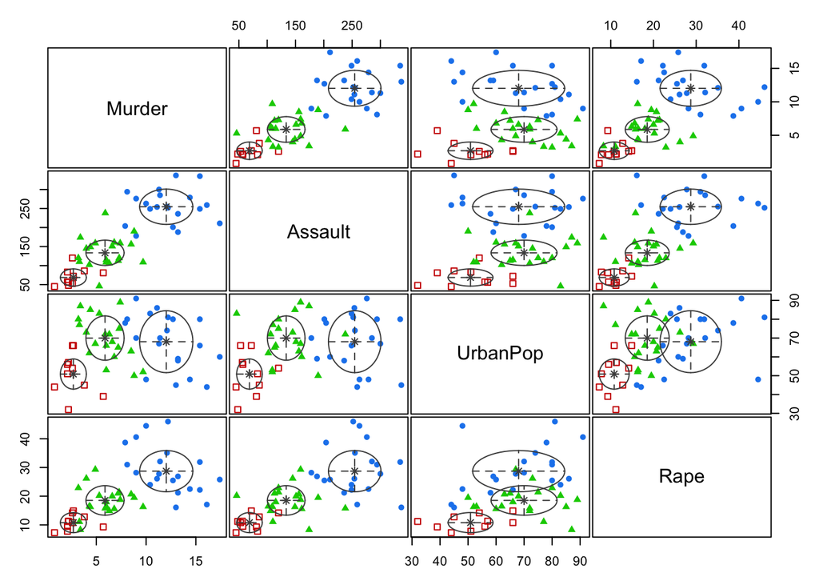

```r
plot(model, what="classification")
```

We can see that the red group (group2) seems to represent the group of states with the lowest arrest rate. This group also corresponds to the most rural states. States in the blue group (group 1) have a higher arrest rate than those in the green group.